# Лабораторная работа №13

Операционные системы - Бекауов А.Т

Российский университет дружбы народов, Москва, Россия

# Введение

## Цель работы

Цель данной лабораторной работы - научится писать более сложные командные файлы с использованием логических управляющих конструкций и циклов.

# Выполнение лабораторной работы

## Программа №1 - Создание файла

Создаю файл lab13-1.sh для новой программы меняю права доступа, разрешая его выполнение, таким образом файл становится исполняемым.

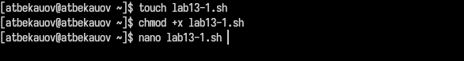

## Программа №1 - Листинг

Открываю файл в редакторе nano и записываю следующий код программы:

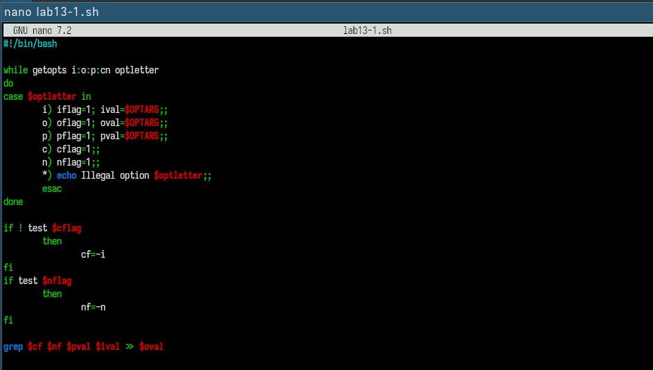

## Программа №1 - Выполнение

Сохраняю файл и закрываю редактор nano, далее запускаю исполняемый файл с помощью команды bash. Затем проверяю, что файл нашёл в программе hello.cpp строчки содержащие hello и вывел их в файл output.txt.

[figure not shown]

## Программа №2 - Создание файлов

Создаю файл lab13-2.sh, меняю права доступа, разрешая его выполнение. Также создаю файл num.c - Программу на C

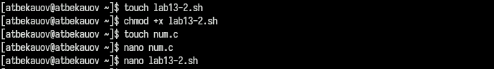

## Программа №2 - Листинг num.c

Открываю файл num.c в nano и ввожу следующий текст программы на C:

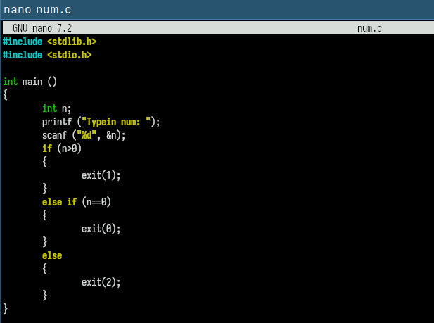

## Программа №2 - Листинг lab13-2.sh

Затем открываю в nano файл lab13-2.sh и ввожу следующую программу:

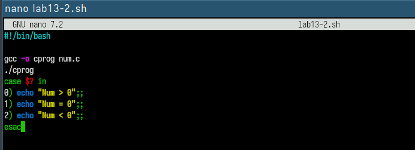

## Программа №2 - Выполнение

Сохраняю файл, выхожу из nano и запускую файл через bash. Сначала скрипт запускает программу num.c, которая просит на вход число. Затем num.c выходит с соответствующим кодом и скрипт считывает его выводя соответствующее выражение

[figure not shown]

## Программа №3 - Создание файла

Создаю файл lab13-3.sh, меняю права доступа, разрешая его выполнение. Открываю файл в nano

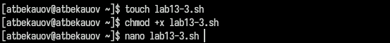

## Программа №3 - Листинг

Далее ввожу следующий текст программы:

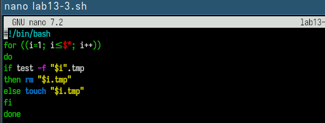

## Программа №3 - Выполнение

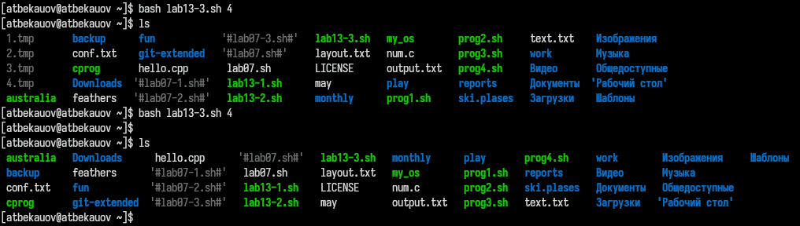

## Программа №4 - Создание файла

Создаю файл lab13-4.sh, меняю права доступа, разрешая его выполнение. Открываю файл в nano

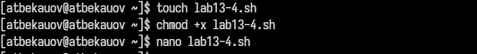

## Программа №4 - Листинг

Далее ввожу следующий текст программы:

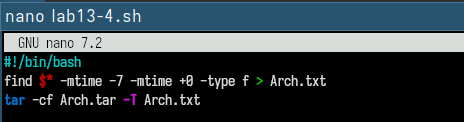

## Программа №4 - Выполнение

Сохраняю файл, выхожу из nano и запускую файл через bash, скрипт создал два файла - первый текстовый, который содержит имена архивируемых файлов, второй - архив этих файлов.

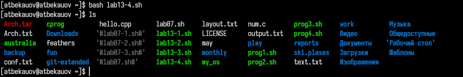

# Заключение

## Выводы

В ходе данной лаботраторной работы я научился писать более сложные командные файлы с использованием логических управляющих конструкций и циклов.